# Lab 2

https://github.com/rvp3011/Lab0

# 1. Briefly describe the data set. What information does it contain?

The dataset is an avacado price data set from kaggle, which contains data regarding avacado sales in the United States from 2015 to 2020. There is a total of 33,045 records with 13 different variables. The variables are listed below:

Date - The Date of the Observation

average_price - The average price of an avacado

total_volume - The total number of avacado sold

4046 - small hass avacado

4225 - large hass avacado

4770 - extra large hass avacado

total_bags - The total number of avacados sold in bags

small_bags - The number of avocados sold in small bags

large_bags - The number of avocados sold in large bags

xlarge_bags - The number of avocados sold in extra large bags

type - Type of avacado sold, organic or conventional

year - The year sold

geography - The city/region where the avacado was sold

# 2. Clean the data in any way you see fit.

```python
    #| label: clean-data
    #| echo: true
    import pandas as pd
    import numpy as np
    from plotnine import ggplot, aes, geom_point, scale_y_log10, labs, scale_y_continuous, scale_size_continuous, guides, theme_minimal, geom_text, geom_boxplot, theme, element_text, facet_wrap, geom_bar, geom_smooth
    df = pd.read_csv("Data/avocado-updated-2020.csv")
    df = df.rename({"4046": "small_hass"}, axis=1)
    df = df.rename({"4225": "large_hass"}, axis=1)
    df = df.rename({"4770": "xlarge_hass"}, axis=1)

    city_list = [
    "Albany", "Atlanta", "Baltimore/Washington", "Boise", "Boston",
    "Buffalo/Rochester", "Charlotte", "Chicago", "Cincinnati/Dayton",
    "Columbus", "Dallas/Ft. Worth", "Denver", "Detroit", "Grand Rapids",
    "Harrisburg/Scranton", "Hartford/Springfield", "Houston",
    "Indianapolis", "Jacksonville", "Las Vegas", "Los Angeles",
    "Louisville", "Miami/Ft. Lauderdale", "Nashville", "New Orleans/Mobile",
    "New York", "Orlando", "Philadelphia", "Phoenix/Tucson", "Pittsburgh",
    "Portland", "Raleigh/Greensboro", "Richmond/Norfolk", "Roanoke",
    "Sacramento", "San Diego", "San Francisco", "Seattle", "Spokane",
    "St. Louis", "Syracuse", "Tampa", "WestTex/New Mexico"
]

    def geo_type(name):
      if name == "Total U.S.":
        return "country"
      elif name in ["West", "Northeast", "Southeast", "SouthCentral", "Midsouth", "Plains", "GreatLakes"]:
        return "region"
      elif name in city_list:
        return "city"
      else:
        return "state"
    df_clean = df.copy()
    df_clean["geo_type"] = df["geography"].apply(geo_type)

    df_clean
```

|  | date | average_price | total_volume | small_hass | large_hass | xlarge_hass | total_bags | small_bags | large_bags | xlarge_bags | type | year | geography | geo_type |
| --- | --- | --- | --- | --- | --- | --- | --- | --- | --- | --- | --- | --- | --- | --- |
| 0 | 2015-01-04 | 1.22 | 40873.28 | 2819.50 | 28287.42 | 49.90 | 9716.46 | 9186.93 | 529.53 | 0.00 | conventional | 2015 | Albany | city |
| 1 | 2015-01-04 | 1.79 | 1373.95 | 57.42 | 153.88 | 0.00 | 1162.65 | 1162.65 | 0.00 | 0.00 | organic | 2015 | Albany | city |
| 2 | 2015-01-04 | 1.00 | 435021.49 | 364302.39 | 23821.16 | 82.15 | 46815.79 | 16707.15 | 30108.64 | 0.00 | conventional | 2015 | Atlanta | city |
| 3 | 2015-01-04 | 1.76 | 3846.69 | 1500.15 | 938.35 | 0.00 | 1408.19 | 1071.35 | 336.84 | 0.00 | organic | 2015 | Atlanta | city |
| 4 | 2015-01-04 | 1.08 | 788025.06 | 53987.31 | 552906.04 | 39995.03 | 141136.68 | 137146.07 | 3990.61 | 0.00 | conventional | 2015 | Baltimore/Washington | city |
| ... | ... | ... | ... | ... | ... | ... | ... | ... | ... | ... | ... | ... | ... | ... |
| 33040 | 2020-11-29 | 1.47 | 1583056.27 | 67544.48 | 97996.46 | 2617.17 | 1414878.10 | 906711.52 | 480191.83 | 27974.75 | organic | 2020 | Total U.S. | country |
| 33041 | 2020-11-29 | 0.91 | 5811114.22 | 1352877.53 | 589061.83 | 19741.90 | 3790665.29 | 2197611.02 | 1531530.14 | 61524.13 | conventional | 2020 | West | region |
| 33042 | 2020-11-29 | 1.48 | 289961.27 | 13273.75 | 19341.09 | 636.51 | 256709.92 | 122606.21 | 134103.71 | 0.00 | organic | 2020 | West | region |
| 33043 | 2020-11-29 | 0.67 | 822818.75 | 234688.01 | 80205.15 | 10543.63 | 497381.96 | 285764.11 | 210808.02 | 809.83 | conventional | 2020 | West Tex/New Mexico | state |
| 33044 | 2020-11-29 | 1.35 | 24106.58 | 1236.96 | 617.80 | 1564.98 | 20686.84 | 17824.52 | 2862.32 | 0.00 | organic | 2020 | West Tex/New Mexico | state |

33045 rows × 14 columns

# 3. Which major geographical region sold the most total organic, small Hass avocados in 2017?

```python
    #| label: load-data
    #| echo: true
region_sales = df_clean[
    (df_clean["type"] == "organic") &
    (df_clean["year"] == 2017) &
    (df_clean["geo_type"] == "region")
].groupby("geography")[["small_hass"]].sum().sort_values(by="small_hass", ascending=False)
region_sales
```

| geography | small_hass |
| --- | --- |
| West | 1870206.29 |
| Northeast | 925832.36 |
| Southeast | 285124.34 |
| Midsouth | 186395.50 |
| Plains | 168583.40 |

# Answer = West

# 4. Split the date variable into month, day, and year variables. In which month is the highest average volume of avocado sales?

```python
df_clean["date"] = pd.to_datetime(df_clean["date"])

df_clean["year"] = df_clean["date"].dt.year
df_clean["month"] = df_clean["date"].dt.month
df_clean["day"] = df_clean["date"].dt.day

avg_vol = df_clean.groupby("month")["total_volume"].mean()

highest = avg_vol.idxmax()
print(highest, avg_vol[highest])
```

```
5 1123632.254218107
```

# Answer = May

# 5. Which metro area geographical regions sold the most total avocados? Plot side-by-side box-plots of the total volume for only the five metro geographical regions with the highest averages for the total_volume variable.

```
geography
Los Angeles         9.593505e+08
New York            5.282452e+08
Dallas/Ft. Worth    4.362042e+08
Houston             4.208438e+08
Phoenix/Tucson      3.825234e+08
Name: total_volume, dtype: float64
```

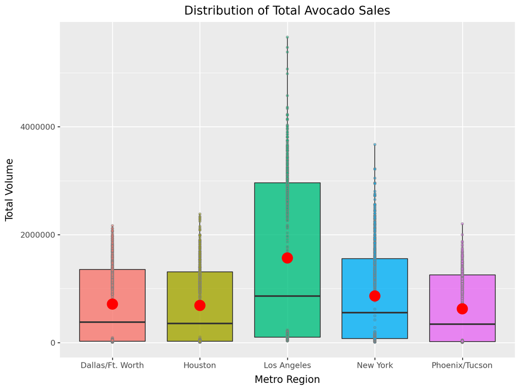

```python
city_df = df_clean[df_clean["geo_type"] == "city"]

top_cities = (
    city_df.groupby("geography")["total_volume"]
    .sum()
    .sort_values(ascending=False)
    .head(5)
)

print(top_cities)

top5_names = top_cities.index.tolist()
top5_df = city_df[city_df["geography"].isin(top5_names)]
means_df = (
    top5_df.groupby("geography", as_index=False)["total_volume"]
    .mean()
)

(
    ggplot(top5_df, aes(x="geography", y="total_volume", fill="geography"))
    + geom_boxplot(alpha=0.8)
    + geom_point(alpha=0.5, size=1, color="gray")
    + geom_point(
        data=means_df,
        mapping=aes(x="geography", y="total_volume"),
        color="red",
        size=6,
        fill="red",
    )

    + labs(
        title="Distribution of Total Avocado Sales",
        x="Metro Region",
        y="Total Volume"
    )
    + theme(
        figure_size=(8, 6),
        legend_position="none"
    )

)
```

# Answer = Los Angeles

# 6. From your cleaned data set, create a data set with only these California regions and answer the following questions about these California regions only.

```python
ca_df = df_clean[(df_clean["geography"] == "Los Angeles") | (df_clean["geography"] == "San Diego") | (df_clean["geography"] == "Sacramento") | (df_clean["geography"] == "San Francisco")]
ca_df
```

|  | date | average_price | total_volume | small_hass | large_hass | xlarge_hass | total_bags | small_bags | large_bags | xlarge_bags | type | year | geography | geo_type | month | day |
| --- | --- | --- | --- | --- | --- | --- | --- | --- | --- | --- | --- | --- | --- | --- | --- | --- |
| 44 | 2015-01-04 | 0.85 | 2682159.95 | 1837999.65 | 524430.47 | 64225.78 | 255504.05 | 215571.80 | 36981.72 | 2950.53 | conventional | 2015 | Los Angeles | city | 1 | 4 |
| 45 | 2015-01-04 | 1.25 | 54495.54 | 47721.51 | 1723.40 | 0.00 | 5050.63 | 5050.63 | 0.00 | 0.00 | organic | 2015 | Los Angeles | city | 1 | 4 |
| 80 | 2015-01-04 | 1.05 | 430138.88 | 110693.69 | 270107.61 | 9737.50 | 39600.08 | 39600.08 | 0.00 | 0.00 | conventional | 2015 | Sacramento | city | 1 | 4 |
| 81 | 2015-01-04 | 1.33 | 9213.49 | 3727.52 | 4327.52 | 0.00 | 1158.45 | 1158.45 | 0.00 | 0.00 | organic | 2015 | Sacramento | city | 1 | 4 |
| 82 | 2015-01-04 | 0.94 | 461607.33 | 244152.26 | 165299.33 | 15302.75 | 36852.99 | 30884.29 | 5595.00 | 373.70 | conventional | 2015 | San Diego | city | 1 | 4 |
| ... | ... | ... | ... | ... | ... | ... | ... | ... | ... | ... | ... | ... | ... | ... | ... | ... |
| 33018 | 2020-11-29 | 1.43 | 23531.38 | 3303.69 | 2057.03 | 0.00 | 18170.66 | 18144.54 | 26.12 | 0.00 | organic | 2020 | Sacramento | city | 11 | 29 |
| 33019 | 2020-11-29 | 1.12 | 469356.72 | 104509.99 | 19988.45 | 7210.47 | 337647.81 | 189341.36 | 127701.64 | 20604.81 | conventional | 2020 | San Diego | city | 11 | 29 |
| 33020 | 2020-11-29 | 1.95 | 25799.95 | 894.63 | 838.11 | 0.00 | 24067.21 | 9691.46 | 14375.75 | 0.00 | organic | 2020 | San Diego | city | 11 | 29 |
| 33021 | 2020-11-29 | 1.50 | 644141.37 | 128555.43 | 136718.24 | 5597.21 | 373270.49 | 159276.65 | 207760.32 | 6233.52 | conventional | 2020 | San Francisco | city | 11 | 29 |
| 33022 | 2020-11-29 | 1.87 | 59527.02 | 2815.23 | 4542.30 | 0.00 | 52169.49 | 52034.33 | 135.16 | 0.00 | organic | 2020 | San Francisco | city | 11 | 29 |

2448 rows × 16 columns

# 7. In which California regions is the price of organic versus conventional avocados most different? Support your answer with a few summary statistics AND a visualization.

```
type           conventional   organic  price_diff
geography
Los Angeles        1.047124  1.574902    0.527778
Sacramento         1.295359  1.873856    0.578497
San Diego          1.113856  1.798366    0.684510
San Francisco      1.400490  2.119444    0.718954
```

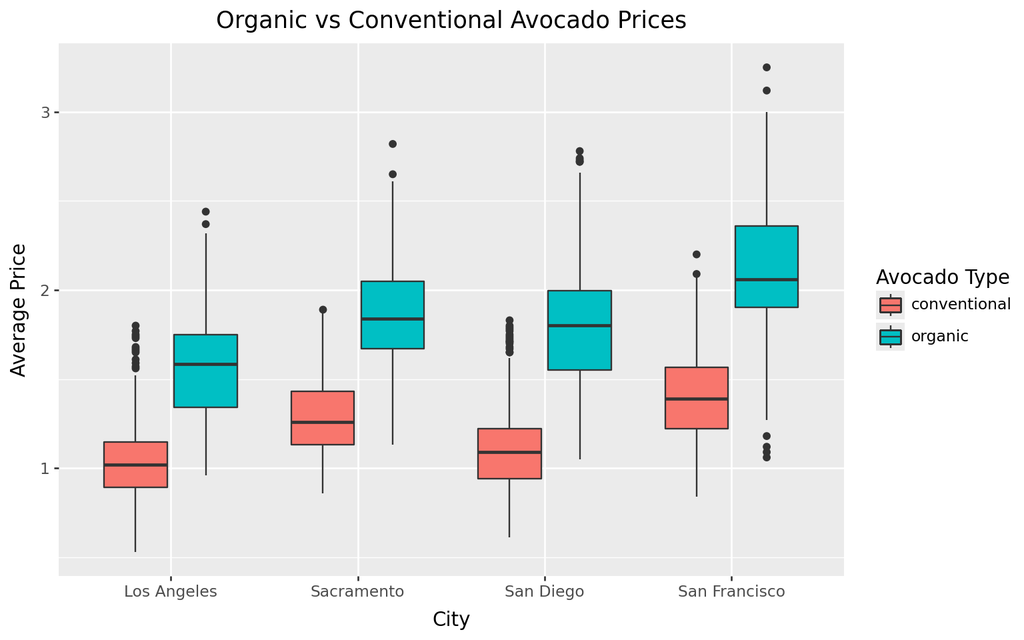

```python
avg_price = ca_df.groupby(["geography", "type"])["average_price"].mean().reset_index()

price_diff = avg_price.pivot(index="geography", columns="type", values="average_price")

price_diff["price_diff"] = (price_diff["organic"] - price_diff["conventional"]).abs()

print(price_diff)

(
    ggplot(ca_df, aes(x="geography", y="average_price", fill="type"))
    + geom_boxplot()
    + labs(
        title="Organic vs Conventional Avocado Prices",
        x="City",
        y="Average Price"
    )
    + theme(
        figure_size=(8, 5),
        legend_title=element_text(text="Avocado Type")
    )
)
```

# Answer = San Francisco

# 8. The following plot shows, for all four California regions, the proportion of the average Hass avocado sales that are small, large, or extra large; conventional vs. organic. Recreate the plot; you do not have to replicate the exact finishing touches - e.g., color, theme - but your plot should resemble the content of this plot.

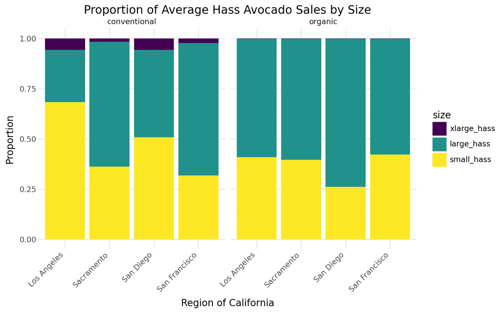

```python
sizes = (
    ca_df.melt(
        id_vars=["geography", "type", "date"],
        value_vars=["small_hass", "large_hass", "xlarge_hass"],
        var_name="size",
        value_name="units"
    )
)

avg_units = (
    sizes.groupby(["geography", "type", "size"], as_index=False)["units"]
              .mean()
)

avg_units["total_city_type"] = avg_units.groupby(["geography", "type"])["units"].transform("sum")
avg_units["proportion"] = avg_units["units"] / avg_units["total_city_type"]

avg_units["size"] = pd.Categorical(
    avg_units["size"],
    categories=["xlarge_hass", "large_hass", "small_hass"],
    ordered=True
)

(
    ggplot(avg_units, aes(x="geography", y="proportion", fill="size"))
    + geom_bar(stat="identity")
    + facet_wrap("~type")
    + labs(
        title="Proportion of Average Hass Avocado Sales by Size",
        x="Region of California",
        y="Proportion"
    )
    + theme_minimal()
    + theme(
        figure_size=(8, 5),
        axis_text_x=element_text(rotation=45, ha="right")
    )
)
```

# House Data Merge

```
       geography          type  avg_avocado_price  avg_total_volume  \
0    Los Angeles  conventional           1.047124      3.034887e+06
1    Los Angeles       organic           1.574902      1.002451e+05
2     Sacramento  conventional           1.295359      4.764038e+05
3     Sacramento       organic           1.873856      1.141100e+04
4      San Diego  conventional           1.113856      5.485435e+05
5      San Diego       organic           1.798366      1.931413e+04
6  San Francisco  conventional           1.400490      8.617761e+05
7  San Francisco       organic           2.119444      3.435755e+04

   avg_house_price
0     9.549506e+05
1     9.549506e+05
2     5.850244e+05
3     5.850244e+05
4     9.363254e+05
5     9.363254e+05
6     1.129449e+06
7     1.129449e+06
```

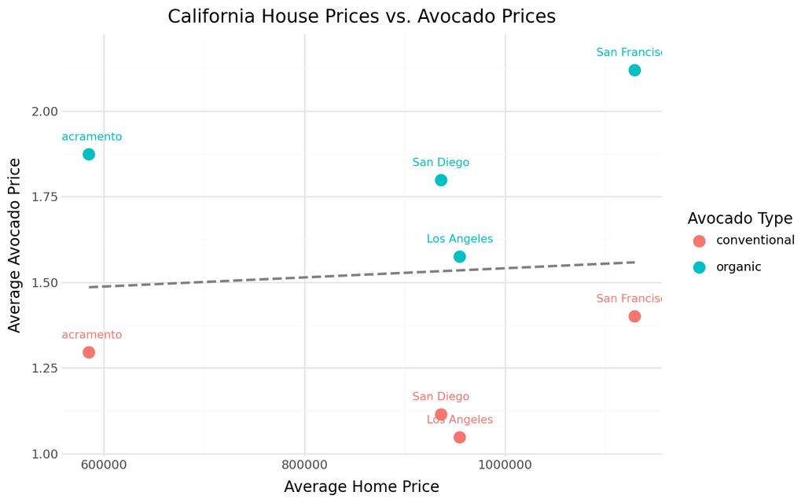

```python
zillow = pd.read_csv("Data/Metro_zhvi_uc_sfrcondo_tier_0.33_0.67_sm_sa_month.csv")
zillow_ca = zillow.loc[
    (zillow["RegionName"] == "Los Angeles, CA") |
    (zillow["RegionName"] == "San Diego, CA") |
    (zillow["RegionName"] == "San Francisco, CA") |
    (zillow["RegionName"] == "Sacramento, CA")
].copy()

cols = zillow.columns[-12:]
zillow_ca["avg_house_price"] = zillow_ca[cols].mean(axis=1)

zillow_ca_latest = zillow_ca[["RegionName", "StateName", "avg_house_price"]].copy()


zillow_ca_latest["geography"] = zillow_ca_latest["RegionName"].replace({
    "Los Angeles, CA": "Los Angeles",
    "San Diego, CA": "San Diego",
    "San Francisco, CA": "San Francisco",
    "Sacramento, CA": "Sacramento"
})

zillow_ca_latest = zillow_ca_latest[["geography", "avg_house_price"]]



avocado_summary = (
    ca_df.groupby(["geography", "type"], as_index=False)
         .agg(
             avg_avocado_price=("average_price", "mean"),
             avg_total_volume=("total_volume", "mean")
         )
)

merged = avocado_summary.merge(zillow_ca_latest, on="geography", how="left")
print(merged)

(
    ggplot(merged, aes(x="avg_house_price", y="avg_avocado_price", color="type"))
    + geom_point(size=4)
    + geom_text(aes(label="geography"), nudge_y=0.05, size=8)
    + geom_smooth(method="lm", se=False, linetype="dashed", color="gray")
    + labs(
        title="California House Prices vs. Avocado Prices",
        x="Average Home Price",
        y="Average Avocado Price",
        color="Avocado Type"
    )
    + theme_minimal()
    + theme(
        figure_size=(8, 5)
    )
)
```

Based on the evidence from the graph and dataset I would argue that avocado toast is not the reason why millenials can’t afford houses. The scatterplot above shows that there isn’t much correlation between the avocado prices and home prices. Although areas like San Francisco have high home prices and avocado prices, areas like Sacramento have relatively lower home prices with relatively high avocado prices. The scatterplot having data scattered around in different areas like that, shows that there is very weak correlation here. If there was a causal effect it is extremely unlikely to see a distribution with such weak correlation like this. Avocado toast is not why millenials can’t afford houses.